# Econ104Project

Mason Lee, Ian Bowen

2025-03-05

```r
library(tidyverse)
```

```r
library(ggplot2)
library(MASS)
library(dplyr)
library(corrplot)
```

# Section 1

## Data

```r
all_car_adverts <- read_csv("all_car_adverts.csv")
```

```
## ──────────────────────────────────────────────────────── Delimiter: "," chr
## (16): make, model, variant, car_badges, car_title, car_sub_title, car_at... dbl
## (16): ...1, car_price, car_seller_rating, miles, engine_vol, engine_size...
```

```r
car_data <- all_car_adverts[c(5, 12, 14, 17, 19, 23)]

car_data$year <- as.numeric(car_data$year)
car_data <- car_data %>%
  filter(car_price < 150000 & car_price > 0)

car_data <- na.omit(car_data)
```

### Variables

The modified car dataset has 6 variables: car_price, car_seller_rating, year, miles, engine_size, and num_owner. We will using the seller rating, car mileage, size of engine and number of previous owners to predict the year the car was built and how much the car is offered for. Year and Price should be correllated, which will help with our future VAR model fit, and the four explanatory variables account for much of the variance in the predictors.

## Question 1: Analysis of Variables

### Histograms

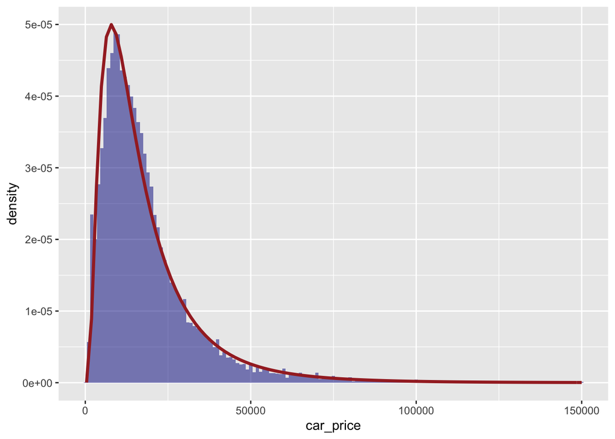

```r
fit_lognorm <- fitdistr(car_data$car_price, "lognormal")


ggplot(data = car_data, aes(x = car_price)) +
  geom_histogram(aes(y = ..density..), binwidth = 1000, fill = "darkblue", alpha = 0.5) +
  stat_function(fun = dlnorm, args = list(meanlog = fit_lognorm$estimate["meanlog"], sdlog = fit_lognorm$estimate["sdlog"]), color = "brown", size = 1.2)
```

The Price variable is a right-skewed variable. There were outliers that were taken our in the Data section of the project. The Price Variable seems best approximated by a Log Normal Distribution (Brown Line). The data fits well, which is usually a good indicator of accuracy for predictors.

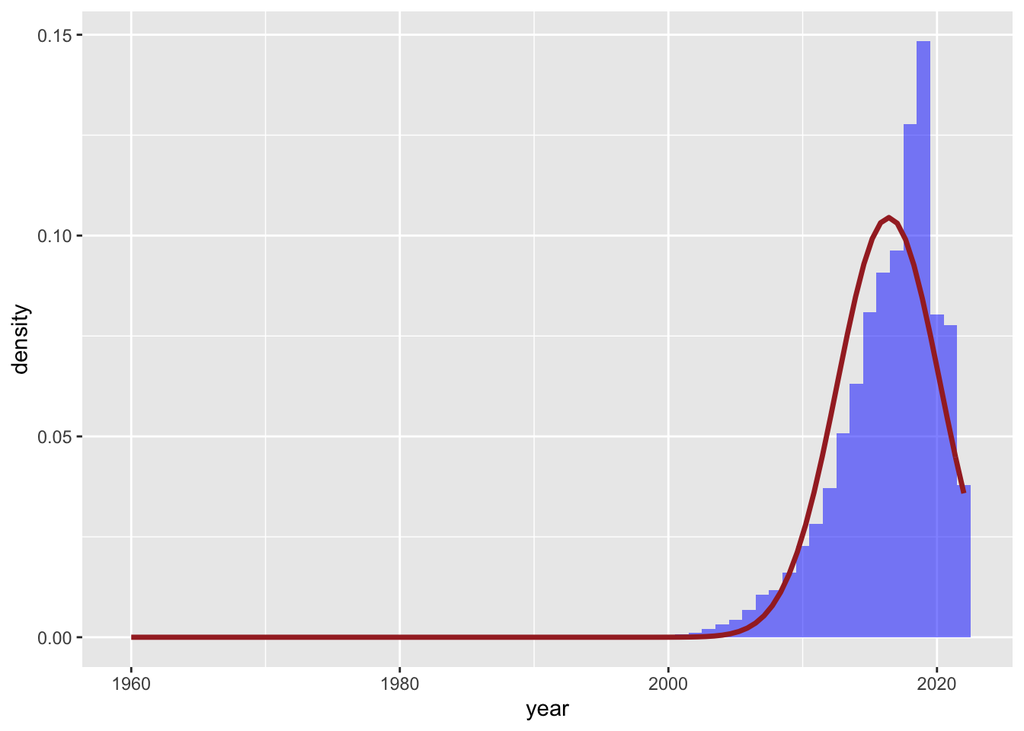

```r
fit_lognorm <- fitdistr(car_data$year, "lognormal")


ggplot(data = car_data, aes(x = year)) +
  geom_histogram(aes(y = ..density..), binwidth = 1, fill = "blue", alpha = 0.5) +
  stat_function(fun = dlnorm, args = list(meanlog = fit_lognorm$estimate["meanlog"], sdlog = fit_lognorm$estimate["sdlog"]), color = "brown", size = 1.2)
```

The year variable is very left skewed. This variable is mostly approximated by a Log Normal curve. The peak isn’t well represented, but the curve does a good job of capturing the rise in the year values. Most of the used cars for sale are from 2019, hence the peak, but aside from that the Log Normal curve fits well.

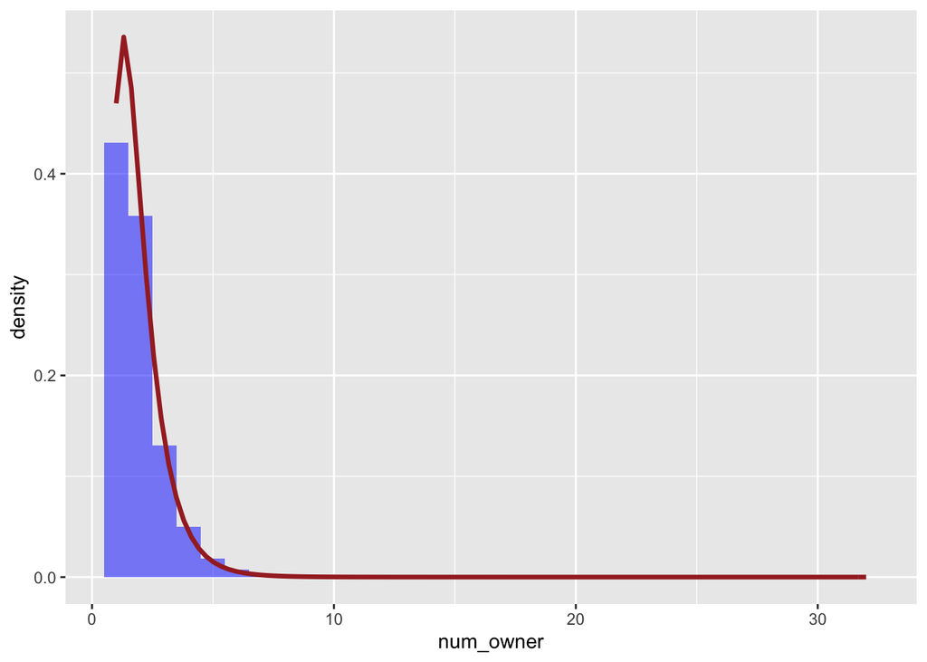

```r
fit_lognorm <- fitdistr(car_data$num_owner, "lognormal")


ggplot(data = car_data, aes(x = num_owner)) +
  geom_histogram(aes(y = ..density..), binwidth = 1, fill = "blue", alpha = 0.5) +
  stat_function(fun = dlnorm, args = list(meanlog = fit_lognorm$estimate["meanlog"], sdlog = fit_lognorm$estimate["sdlog"]), color = "brown", size = 1.2)
```

Because the Previous Number of Owners is usually a low number (aside from outliers), it is a hard variable to provide a fitted curve for, but the closest option between the main curves (normal, log normal, gamma, exponential, poisson, ect.) was Log Normal. It accurately captures the slope downwards, and gets the shape of the peak correct, just higher than the actual data. Number of Owners being so low is also why the data is very right skewed.

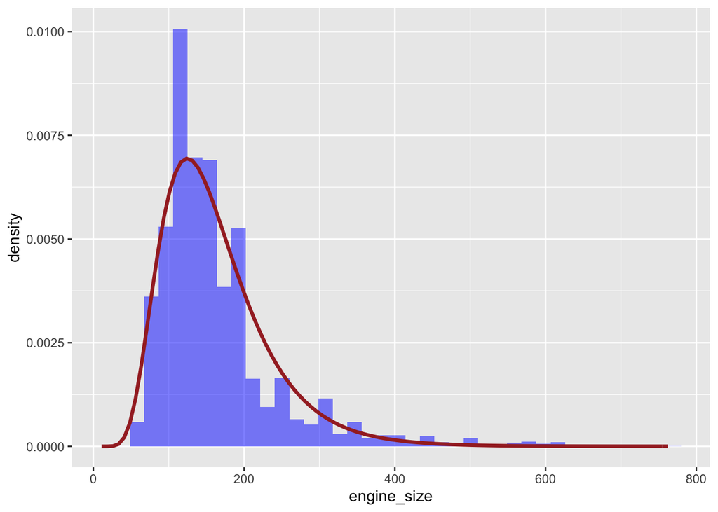

```r
fit_lognorm <- fitdistr(car_data$engine_size, "lognormal")


ggplot(data = car_data, aes(x = engine_size)) +
  geom_histogram(aes(y = ..density..), bins = 40, fill = "blue", alpha = 0.5) +
  stat_function(fun = dlnorm, args = list(meanlog = fit_lognorm$estimate["meanlog"], sdlog = fit_lognorm$estimate["sdlog"]), color = "brown", size = 1.2)
```

Engine Size is a relatively centered variable, with a long tail on the right side. Aside from the unexpected peak at 110, the log normal curve represents the engine_size distribution well. The lower peaks on the right and left sides fit well around the curve, and most of the peak is very accurate. The only issue is the peak, which overexceeds the Log Normal estimation.

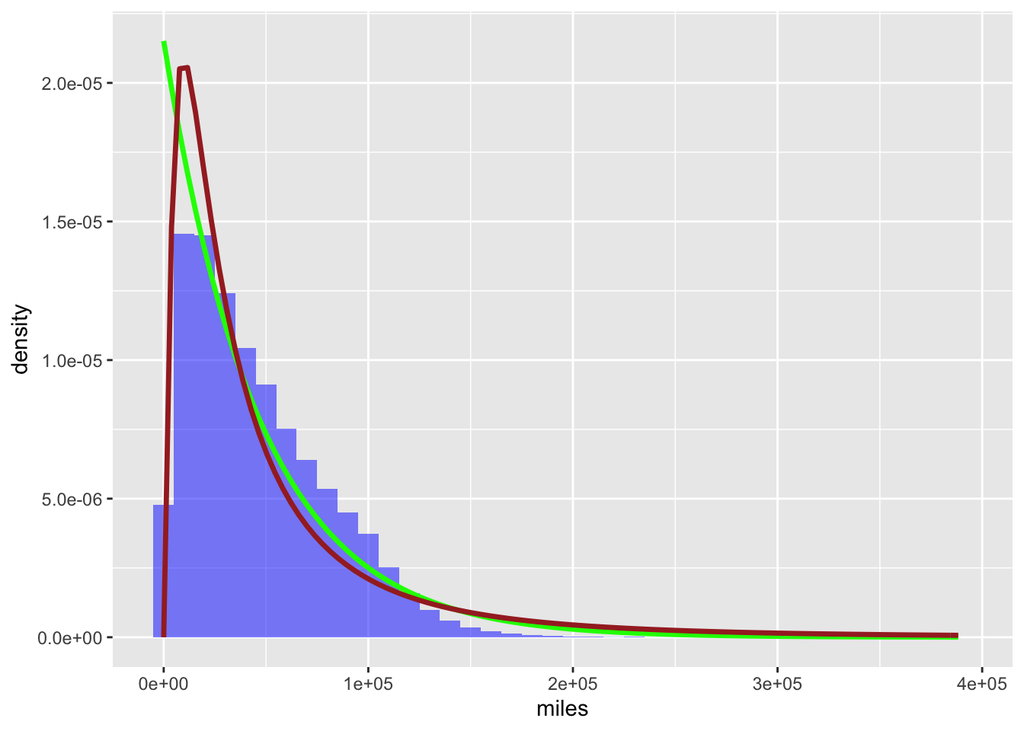

```r
fit_exp <- fitdistr(car_data$miles, "exponential")
fit_lognorm <- fitdistr(car_data$miles, "lognormal")


ggplot(data = car_data, aes(x = miles)) +
  geom_histogram(aes(y = ..density..), binwidth = 10000, fill = "blue", alpha = 0.5) +
  stat_function(fun = dexp, args = list(rate = fit_exp$estimate["rate"]), color = "green", size = 1.2) +
  stat_function(fun = dlnorm, args = list(meanlog = fit_lognorm$estimate["meanlog"], sdlog = fit_lognorm$estimate["sdlog"]), color = "brown", size = 1.2)
```

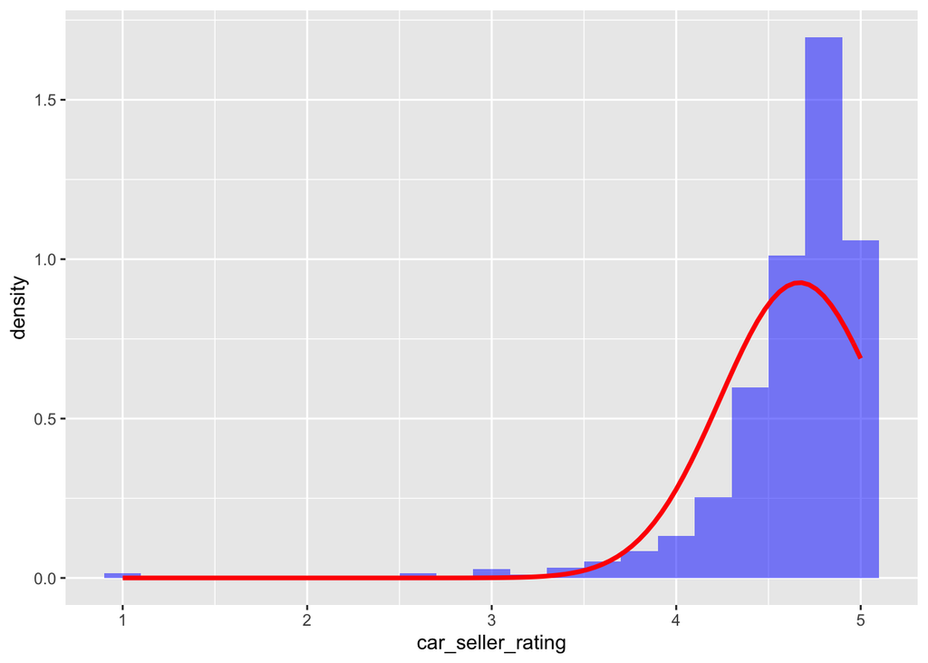

```r
fit_norm <- fitdistr(car_data$car_seller_rating, "normal")


ggplot(data = car_data, aes(x = car_seller_rating)) +
  geom_histogram(aes(y = ..density..), binwidth = 0.2 , fill = "blue", alpha = 0.5) +
  stat_function(fun = dnorm, args = list(mean = mean(car_data$car_seller_rating), sd = sd(car_data$car_seller_rating)), color = "red", size = 1.2)
```

Car Seller Rating is very left skewed, and like with the number of previous owners, the ratings variable is tough to approximate with a statistical curve due to the limited number of options (0-5 scale). That being said, the normal curve (red) seems to approximately capture the data closer than the other options. The upward sloping nature and long left tail fits. The peak contains a higher percentage of the data than expected. I believe this is due to human nature, where more people are likely to give a high score than random generation would expect.

### Correlation Plot

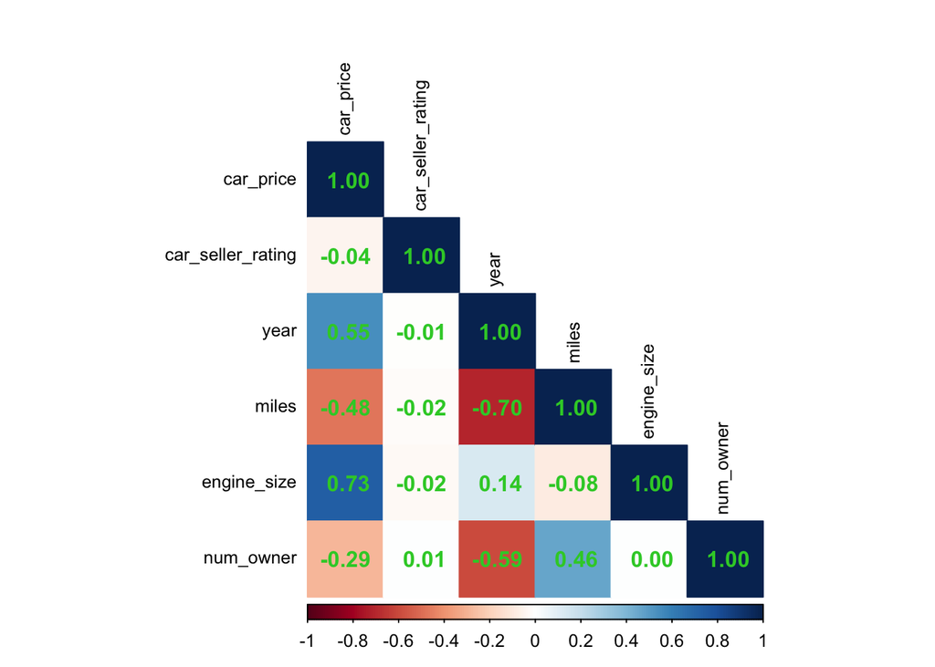

```r
corr_matrix <- cor(car_data)

corrplot(corr_matrix, method = "color", type = "lower", addCoef.col = "limegreen", tl.col = "black", tl.cex = 0.8)
```

This Correlation Plot, generated with the corrplot library, provides a quick way to see how closely variables are correlated with each other. The darker the color, the more significant the correlation.

One takeaway that I noticed was the lack of correlation between seller rating and all other categories. I originally expected there to be a correlation between this variable and price (more trustworthy salesmen may be able to sell for more than their less trustworthy counterparts), but this isn’t reflected in the data. From this point forward I will be omitting this variable from models.

Another thing I notes was the strong negative correlation between number of owners and year. This makes sense, given most people own cars for multiple years before selling them. The -0.7 correlation between miles and year was stronger than I expected, but makes sense as it takes time to accumulate mileage.

The Number of Owners variable having a correlation of 0 with Engine Size is great because there shouldn’t be any relationship between the two varaibles.

The 0.55 correlation between Years and Price is great for the VAR test that will be run later in the project.

### Boxplot

Because of the large number of observations (320,000) being handled, Boxplots become a little difficult to read, but they still provide important information on the variable skew, quartiles, and density.

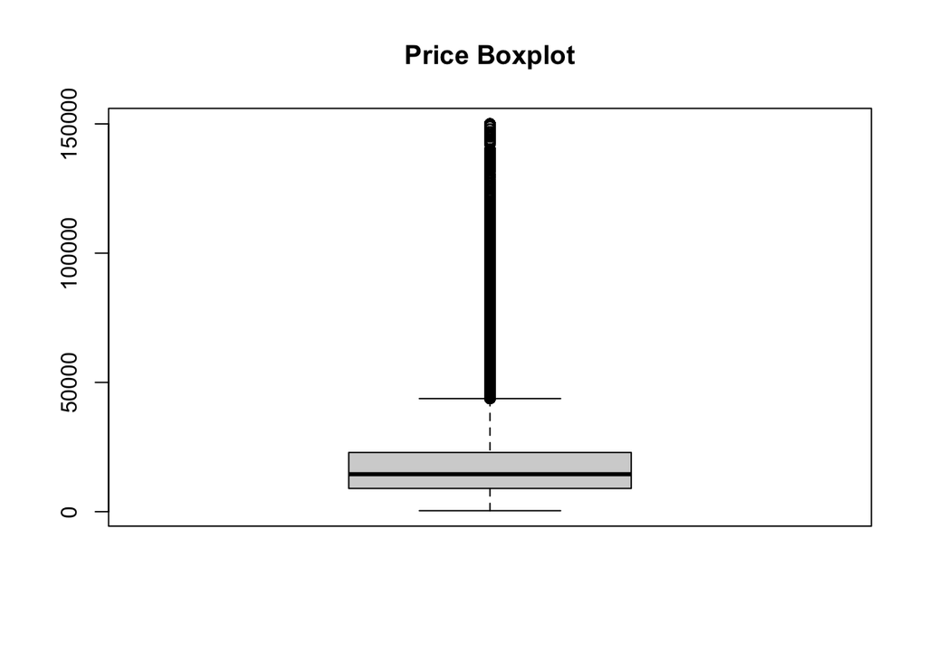

```r
boxplot(car_data$car_price, main = "Price Boxplot")
```

The Price boxplot shows a strong right skew, with the data centered around 15,000 dollars and only about 25% above 25,000 dollars. There are many cars being sold for very cheap, but a steady number being sold for well above average, too, as shown by how solid the stream of dots above the outlier line looks.

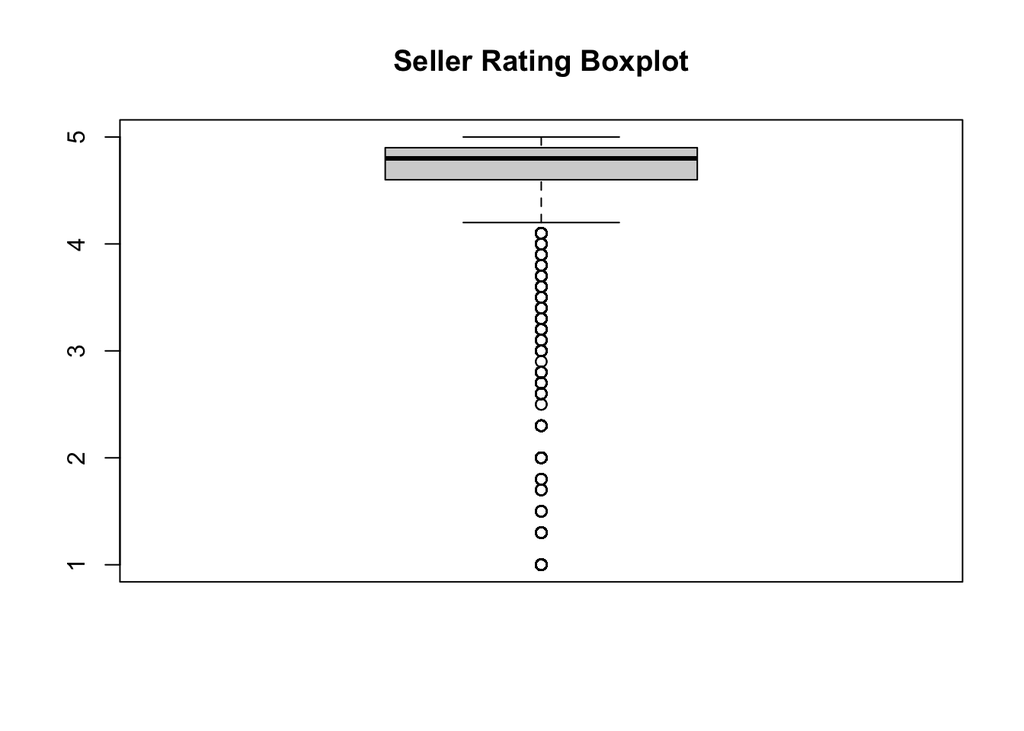

```r
boxplot(car_data$car_seller_rating, main = "Seller Rating Boxplot")
```

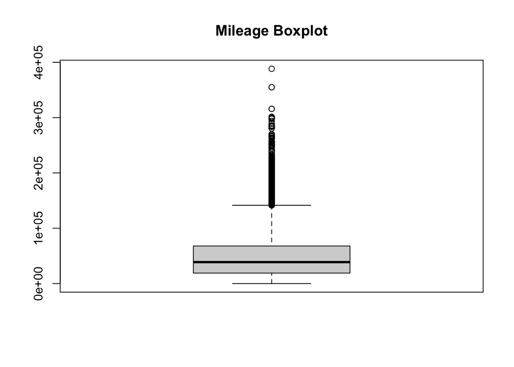

```r
boxplot(car_data$miles, main = "Mileage Boxplot")
```

The mileage boxplot is pretty standard. The average car has been driven somewhere around 50,000 miles, with outliers rampant but becoming less uncommon as they distances become higher. The spread is nice, too, which helps with modeling because it means that the data isn’t all grouped together like with the Ratings.

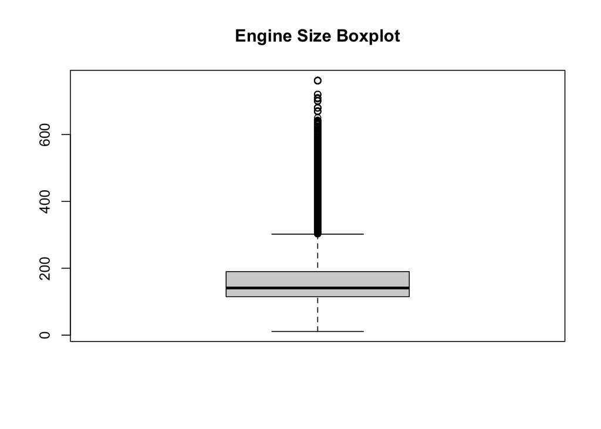

```r
boxplot(car_data$engine_size, main = "Engine Size Boxplot")
```

This boxplot is better than I expected. Because most engines come in a series of standard sizes, I expected this boxplot to suffer the same issues as the Ratings plot, but it actually looks much more like the Mileage one. The spread between quartiles is a little smaller but still statistically significant, and the outliers trail off better than they do in the Price boxplot

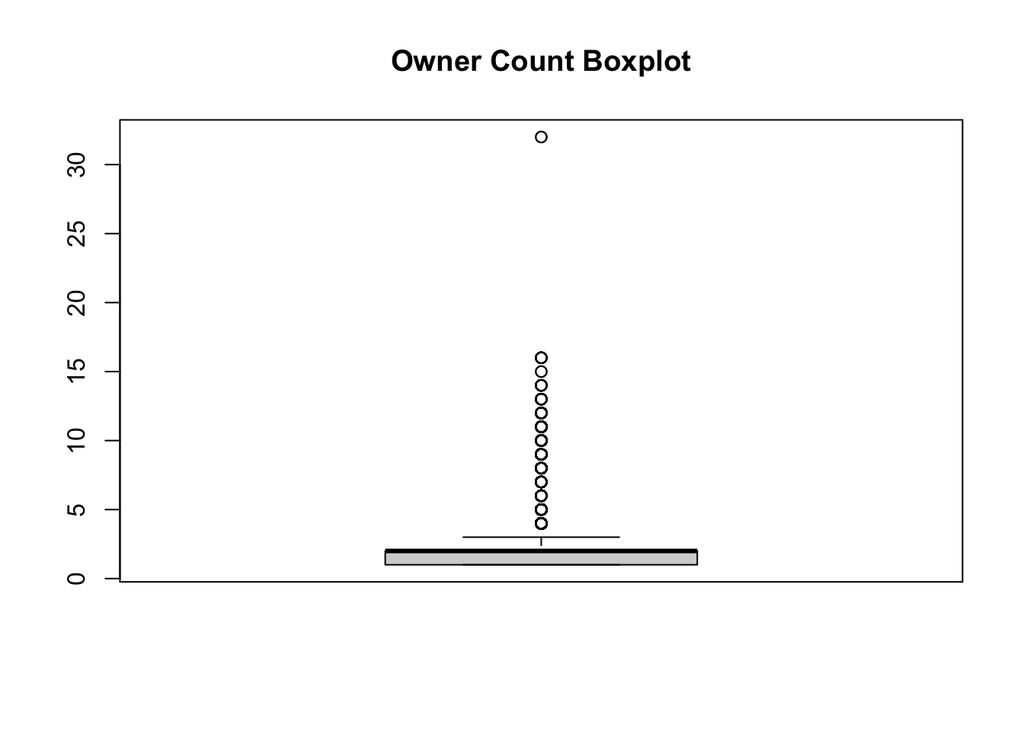

```r
boxplot(car_data$num_owner, main = "Owner Count Boxplot")
```

If it weren’t for the correlation graph above, I would think that this boxplot would be a horrible indicator for modeling with the Owner Count Varaible, but the very low number of outliers makes up for the low quartile spread. The average number of times a car is sold is around 2, with 25% being sold secondhand for the first time. Being sold more than 3 times is considered an outlier. There is no lower outlier line because you can’t have less than one previus owner.

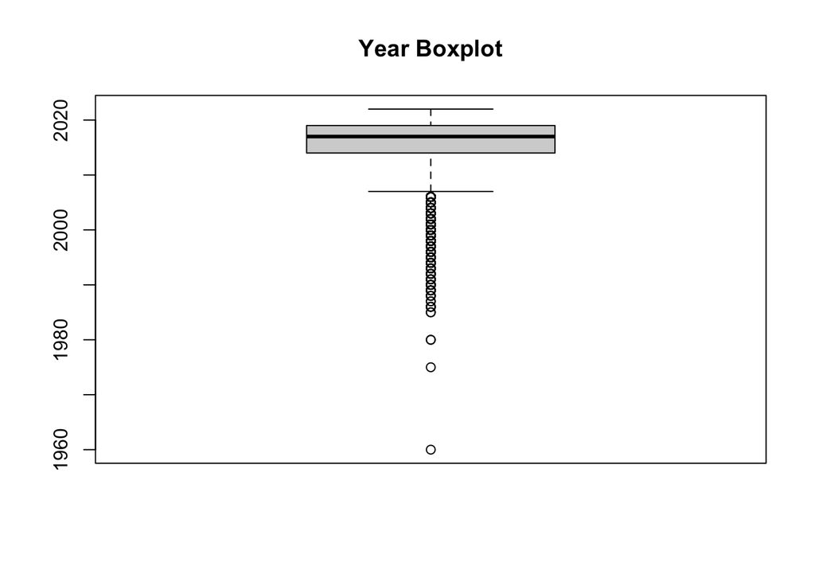

```r
boxplot(car_data$year, main = "Year Boxplot")
```